# wow

Looking out the window of the shoebox I rent in downtown Fayetteville, I wonder: "Who on Earth can afford *more* than a shoebox in downtown Fayetteville?" I get it, though. The city is great, and it has a long and rich history. Maybe someday I'll have a chance of even owning a shoebox in Fayetteville!

Years ago, a team of Bostonites wanted to know if the city's renters had a chance of becoming the city's "owners." They asked "Who owns what in Boston?" They used property and assessor data to build key insights in hopes of answering the question. I'd like to do something similar. So I ask: Who owns what in Fayetteville?

- Is the city's ownership well-divided? Or do a handful of entities own most of the property?
- How common is single property-ownership?
- Do multi-parcel owning entities have a pattern to their ownership? Is it concentrated or spread out?

The data provided by the city, although very good, ([Link](https://maps.fayetteville-ar.gov/viewer/index.html?webmap=ec0840ee722a44839d4f5e3e01cb00c4)) does not include a dataset containing both land parcel and ownership records. In fact, parcel ownership data is not made available for download anywhere. So I ended up sending many GET requests -- for 2000 items each -- netting 60,000+ parcel / ownership objects to map to the publicly available geospatial data.

First we import some essential modules.

```python
import os
import json
import pandas as pd
import geopandas as gpd
import requests
```

The data connecting parcels to owners is spread out among many json files. We'll loop through them and combine them into a single, clean dataframe.

```python
# set dir to parcel data
directory = './parcels'

# init empty dataframe
df = pd.DataFrame()

# loop through parcel data files and add them to our main data frame
for filename in os.listdir(directory):
    filepath = os.path.join(directory, filename)
    f = open(filepath)
    # load file json
    data = json.load(f)
    # make new dataframe from 'features' of json
    datFrame = pd.DataFrame()
    datSeries = pd.Series(data['features'])

    for index, row in datSeries.iteritems():
        attr = row['attributes']
        datFrame = datFrame.append(attr, ignore_index=True)

    df = df.append(datFrame)
```

We'll then save the data so we can use it later or share it easily.

```python
# our indexes went from 0 - 1999, repeating ~ 34 times
# reset them to start at 0
df = df.reset_index(drop=True)
# save data to disk
df.to_pickle('./parcels.pkl')
df.to_csv('./parcels.csv')
```

We'd like to connect this ownership data to a geodatabase for visual analysis. We start by loading the geodatabase file.

```python
fay = gpd.read_file('./Parcel.gdb')
# drop unkown / duplicate PINS
fay = fay.drop_duplicates(subset='PIN')
```

We can also plot it to make sure we're not in the wrong city.

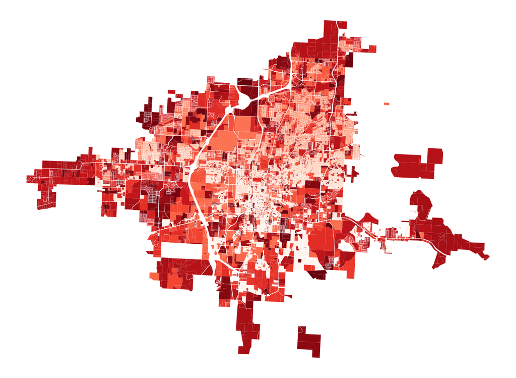

```python
fay.plot(cmap='Reds', figsize=(20,20)).set_axis_off()
```

There she is! How pretty :)

Lets add our new ownership data to the geodatabase.

```python
parcels = pd.read_pickle('parcels.pkl')
# drop dupes
parcels = parcels.drop_duplicates(subset='PARCELID')
```

```python
# tie owners to the parcels they own
owners = parcels[['PARCELID', 'OWNERNME1', 'PSTLADDRESS', 'PSTLCITY', 'PSTLSTATE', 'ACRES', 'URL']].rename(columns={'PARCELID': 'PIN', 'OWNERNME1': 'Owner'})
# add to our geo data
fay = fay.merge(owners, on='PIN')
fay = fay[['PIN', 'Owner', 'Shape_Length', 'Shape_Area', 'PSTLADDRESS', 'PSTLCITY', 'PSTLSTATE', 'ACRES', 'URL', 'geometry']]
# save for the public good
fay.to_file('owners.geojson', driver='GeoJSON')
```

```python
fay = gpd.read_file('owners.geojson')
```

With owners now tied to their parcels in the geospatial data, we can ask some questions. For example: How many owners own only one parcel?

```python
opo = fay['Owner'].value_counts()
opo[opo == 1].shape[0]
```

```
16975
```

So, more than half of the 28,000 parcels in the geospatial data are owned by one-parcel owners. That seems promising for my dream of ownership!

How many own one OR two parcels?

```python
opo[opo <= 2].shape[0]
```

```
18615
```

A few more owners own two parcels. Nice. But what portion of owners is this?

```python
opo[opo <= 2].shape[0] / opo.shape[0]
```

```
0.9395346489678494
```

And what portion of total parcels do they own?

```python
opo[opo <= 2].sum() / opo.sum()
```

```
0.723444531752268
```

So ~94% of Fayetteville's landowners own just 1 or 2 parcels, making up about 72% of total parcel ownership in the city. Again, this seems promising. Even at just 1 parcel owned:

```python
print(str(opo[opo <= 1].shape[0] / opo.shape[0]) + ' ' + str(opo[opo <= 1].sum() / opo.sum()))
```

```
0.8567607126634028 0.6062933066647618
```

It appears that 85% of parcel-owners own just 1 parcel, making up about 60% of total parcel ownership. Not bad metrics at all.

We can visualize these parcels:

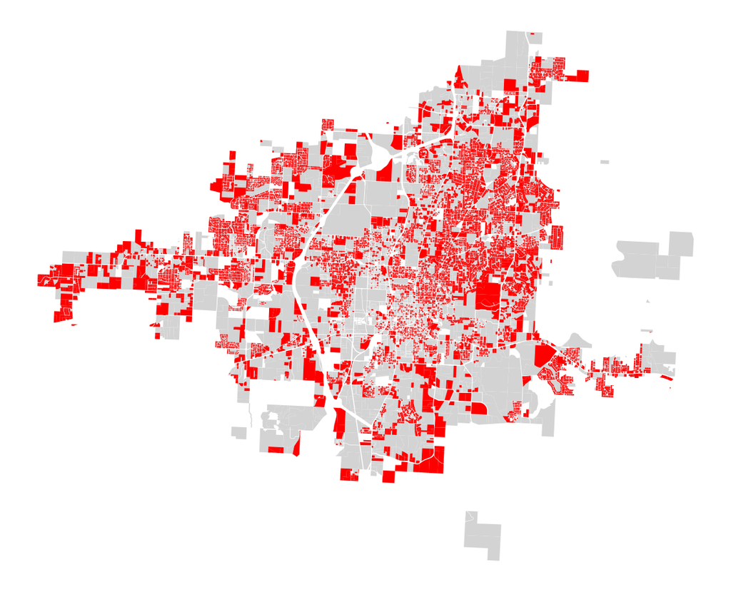

```python
opo = fay['Owner'].value_counts()
names = []
for index, row in opo[opo == 1].iteritems():
    names.append(index)

fbp = fay.plot(figsize=(20, 20), color="lightgray")
fay[fay['Owner'].isin(names)].plot(ax=fbp, color="red", figsize=(20,20)).set_axis_off()
```

One-parcel owners are spread pretty evenly among the city, which again seems like good news for aspiring landowners in the city.

What about owners that own more than a couple parcels? Who owns the most?

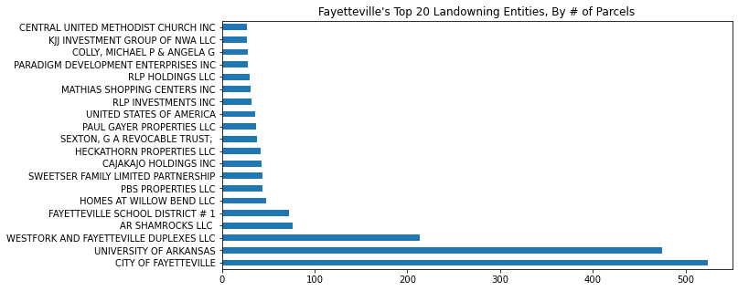

```python
# get number of properties owned by each
oc = fay['Owner'].value_counts()

# plot owners with more than 40 properties
oc.sort_values(ascending = False).head(20).plot(kind='barh', title="Fayetteville's Top 20 Landowning Entities, By # of Parcels", figsize=(10,5))
```

The City of Fayetteville and the University have the Lion's share of parcel ownership.

The University's Land Grab has persisted for a century and a half! We can plot it alongside the City's ownership:

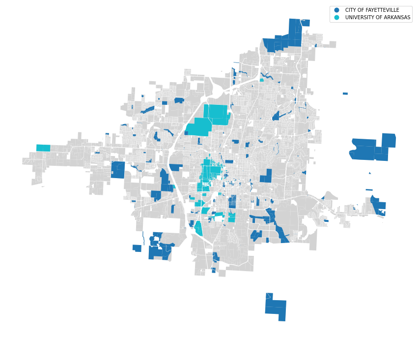

```python
poi = fay[(fay['Owner'] == 'UNIVERSITY OF ARKANSAS') | (fay['Owner'] == 'CITY OF FAYETTEVILLE')]
fbp = fay.plot(figsize=(15, 15), color="lightgray")
poi.plot(ax=fbp, column='Owner', categorical=True, legend=True).set_axis_off()
```

And we can quantify this in terms of area, too:

```python
grouped = fay.groupby(by="Owner").sum()
# Percentage of land owned by the university
uofaArea = grouped[grouped.index == 'UNIVERSITY OF ARKANSAS']['Shape_Area'] / grouped['Shape_Area'].sum()

# Percentage of land owned by the city
cityArea = grouped[grouped.index == 'CITY OF FAYETTEVILLE']['Shape_Area'] / grouped['Shape_Area'].sum()

print(uofaArea[0])
print(cityArea[0])
print(uofaArea[0] + cityArea[0])
```

```
0.049482637519863544
0.1339263261150609
0.18340896363492443
```

By area, the University owns 4.9% of Fayetteville parcels, and combines with the city's 13.3% for a total ~18.3%. This makes sense, as the University plays perhaps *the* central role in the city's economy.

But are there any other big fish? We can take the top 'n' landowners that are not the City, School District, or University, and evaluate them as well.

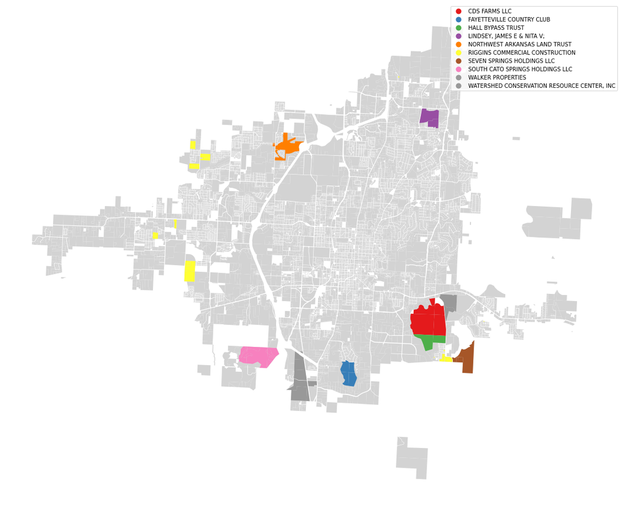

```python
n = 10
topn = grouped[grouped.index.isin(['UNIVERSITY OF ARKANSAS', 'CITY OF FAYETTEVILLE', 'FAYETTEVILLE SCHOOL DISTRICT # 1']) == False]
topn = topn.sort_values('Shape_Area', ascending = False).head(n)
names = []
for index, row in topn.iterrows():
    names.append(index)

poi = fay[(fay['Owner'].isin(names))]
fbp = fay.plot(figsize=(20, 20), color="lightgray")
poi.plot(ax=fbp, column='Owner', cmap='Set1', categorical=True, legend=True).set_axis_off()
```

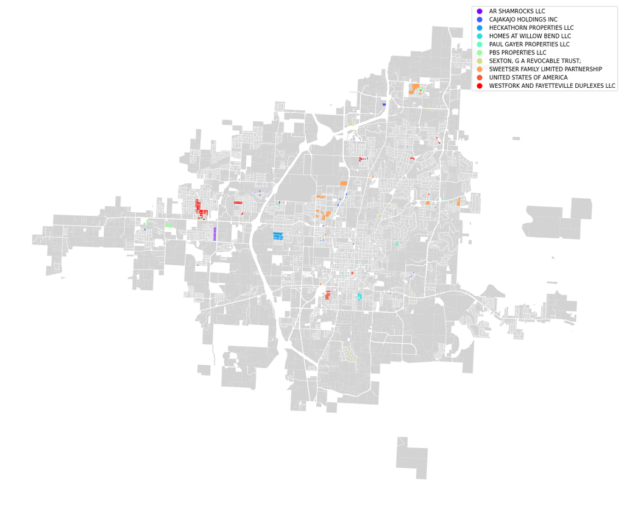

```python
topn = oc[oc.index.isin(['UNIVERSITY OF ARKANSAS', 'CITY OF FAYETTEVILLE', 'FAYETTEVILLE SCHOOL DISTRICT # 1']) == False].head(n)
names = []
for index, row in topn.iteritems():
    names.append(index)
poi = fay[(fay['Owner'].isin(names))]
fbp = fay.plot(figsize=(20, 20), color="lightgray")
poi.plot(ax=fbp, column='Owner', cmap='rainbow', categorical=True, legend=True).set_axis_off()
```

Nothing crazy here, either. Some apartment complexes, duplexes, residential properties, and so on. The usual suspects, it may seem. So what does this mean? Is Fayetteville well-divided in terms of ownership? Maybe not. So far we've only looked at parcel ownership by number and area.

Perhaps a much more important metric is parcel ownership by value. ($$$) It could be that the largest entities are simply the ones with one or two key high-value properties.

This data exists, but is not available for bulk download. [Assessed Value Per Acre, Interactive Map](https://fayetteville-ar.maps.arcgis.com/home/webscene/viewer.html?webscene=a1d709126a3342ff87a39120ce85624f)